# Project: Train a Quadcopter How to Fly

Design an agent to fly a quadcopter, and then train it using a reinforcement learning algorithm of your choice!

Try to apply the techniques you have learnt, but also feel free to come up with innovative ideas and test them.

## Instructions

Take a look at the files in the directory to better understand the structure of the project.

- `task.py`: Define your task (environment) in this file.
- `agents/`: Folder containing reinforcement learning agents.
  - `policy_search.py`: A sample agent has been provided here.
  - `agent.py`: Develop your agent here.
- `physics_sim.py`: This file contains the simulator for the quadcopter. **DO NOT MODIFY THIS FILE**.

For this project, you will define your own task in `task.py`. Although we have provided a example task to get you started, you are encouraged to change it. Later in this notebook, you will learn more about how to amend this file.

You will also design a reinforcement learning agent in `agent.py` to complete your chosen task.

You are welcome to create any additional files to help you to organize your code. For instance, you may find it useful to define a `model.py` file defining any needed neural network architectures.

## Controlling the Quadcopter

We provide a sample agent in the code cell below to show you how to use the sim to control the quadcopter. This agent is even simpler than the sample agent that you'll examine (in `agents/policy_search.py`) later in this notebook!

The agent controls the quadcopter by setting the revolutions per second on each of its four rotors. The provided agent in the `Basic_Agent` class below always selects a random action for each of the four rotors. These four speeds are returned by the `act` method as a list of four floating-point numbers.

For this project, the agent that you will implement in `agents/agent.py` will have a far more intelligent method for selecting actions!

```python
import random

class Basic_Agent():
    def __init__(self, task):
        self.task = task

    def act(self):
        new_thrust = random.gauss(450., 25.)
        return [new_thrust + random.gauss(0., 1.) for x in range(4)]
```

Run the code cell below to have the agent select actions to control the quadcopter.

Feel free to change the provided values of `runtime`, `init_pose`, `init_velocities`, and `init_angle_velocities` below to change the starting conditions of the quadcopter.

The `labels` list below annotates statistics that are saved while running the simulation. All of this information is saved in a text file `data.txt` and stored in the dictionary `results`.

```python
%load_ext autoreload
%autoreload 2

import csv
import numpy as np
from task import Task

# Modify the values below to give the quadcopter a different starting position.
runtime = 5.                                     # time limit of the episode
init_pose = np.array([0., 0., 10., 0., 0., 0.])  # initial pose
init_velocities = np.array([0., 0., 0.])         # initial velocities
init_angle_velocities = np.array([0., 0., 0.])   # initial angle velocities
file_output = 'data.txt'                         # file name for saved results

# Setup
task = Task(init_pose, init_velocities, init_angle_velocities, runtime)
agent = Basic_Agent(task)
done = False
labels = ['time', 'x', 'y', 'z', 'phi', 'theta', 'psi', 'x_velocity',
          'y_velocity', 'z_velocity', 'phi_velocity', 'theta_velocity',
          'psi_velocity', 'rotor_speed1', 'rotor_speed2', 'rotor_speed3', 'rotor_speed4']
results = {x : [] for x in labels}

# Run the simulation, and save the results.
with open(file_output, 'w') as csvfile:
    writer = csv.writer(csvfile)
    writer.writerow(labels)
    while True:
        rotor_speeds = agent.act()
        _, _, done = task.step(rotor_speeds)
        to_write = [task.sim.time] + list(task.sim.pose) + list(task.sim.v) + list(task.sim.angular_v) + list(rotor_speeds)
        for ii in range(len(labels)):
            results[labels[ii]].append(to_write[ii])
        writer.writerow(to_write)
        if done:
            break
```

```
The autoreload extension is already loaded. To reload it, use:
  %reload_ext autoreload
```

[output not shown]

[output not shown]

[output not shown]

[output not shown]

[output not shown]

[output not shown]

[output not shown]

[output not shown]

[output not shown]

[output not shown]

[output not shown]

[output not shown]

[output not shown]

[output not shown]

[output not shown]

[output not shown]

[output not shown]

[output not shown]

[output not shown]

[output not shown]

[output not shown]

[output not shown]

[output not shown]

[output not shown]

[output not shown]

[output not shown]

[output not shown]

[output not shown]

[output not shown]

[output not shown]

[output not shown]

[output not shown]

[output not shown]

[output not shown]

[output not shown]

[output not shown]

[output not shown]

[output not shown]

[output not shown]

[output not shown]

[output not shown]

[output not shown]

[output not shown]

[output not shown]

[output not shown]

[output not shown]

[output not shown]

[output not shown]

[output not shown]

[output not shown]

[output not shown]

[output not shown]

[output not shown]

[output not shown]

[output not shown]

[output not shown]

[output not shown]

[output not shown]

[output not shown]

[output not shown]

[output not shown]

[output not shown]

[output not shown]

[output not shown]

[output not shown]

[output not shown]

[output not shown]

[output not shown]

[output not shown]

[output not shown]

[output not shown]

[output not shown]

[output not shown]

[output not shown]

[output not shown]

[output not shown]

[output not shown]

[output not shown]

[output not shown]

[output not shown]

[output not shown]

[output not shown]

[output not shown]

[output not shown]

[output not shown]

Run the code cell below to visualize how the position of the quadcopter evolved during the simulation.

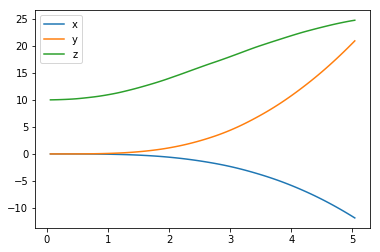

```python
import matplotlib.pyplot as plt
%matplotlib inline

plt.plot(results['time'], results['x'], label='x')
plt.plot(results['time'], results['y'], label='y')
plt.plot(results['time'], results['z'], label='z')
plt.legend()
_ = plt.ylim()
```

The next code cell visualizes the velocity of the quadcopter.

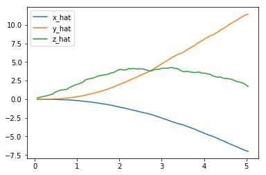

```python
plt.plot(results['time'], results['x_velocity'], label='x_hat')
plt.plot(results['time'], results['y_velocity'], label='y_hat')
plt.plot(results['time'], results['z_velocity'], label='z_hat')
plt.legend()
_ = plt.ylim()
```

Next, you can plot the Euler angles (the rotation of the quadcopter over the $x$-, $y$-, and $z$-axes),

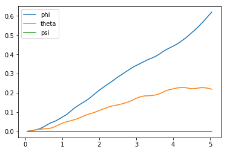

```python
plt.plot(results['time'], results['phi'], label='phi')
plt.plot(results['time'], results['theta'], label='theta')
plt.plot(results['time'], results['psi'], label='psi')
plt.legend()
_ = plt.ylim()
```

before plotting the velocities (in radians per second) corresponding to each of the Euler angles.

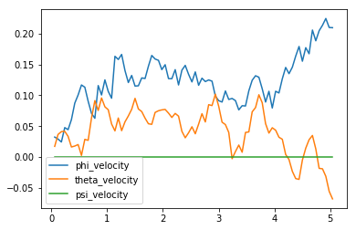

```python
plt.plot(results['time'], results['phi_velocity'], label='phi_velocity')
plt.plot(results['time'], results['theta_velocity'], label='theta_velocity')
plt.plot(results['time'], results['psi_velocity'], label='psi_velocity')
plt.legend()
_ = plt.ylim()
```

Finally, you can use the code cell below to print the agent's choice of actions.

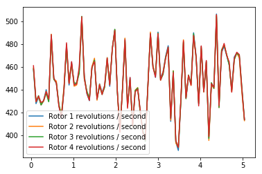

```python
plt.plot(results['time'], results['rotor_speed1'], label='Rotor 1 revolutions / second')
plt.plot(results['time'], results['rotor_speed2'], label='Rotor 2 revolutions / second')
plt.plot(results['time'], results['rotor_speed3'], label='Rotor 3 revolutions / second')
plt.plot(results['time'], results['rotor_speed4'], label='Rotor 4 revolutions / second')
plt.legend()
_ = plt.ylim()
```

When specifying a task, you will derive the environment state from the simulator. Run the code cell below to print the values of the following variables at the end of the simulation:

- `task.sim.pose` (the position of the quadcopter in ($x,y,z$) dimensions and the Euler angles),
- `task.sim.v` (the velocity of the quadcopter in ($x,y,z$) dimensions), and
- `task.sim.angular_v` (radians/second for each of the three Euler angles).

```python
# the pose, velocity, and angular velocity of the quadcopter at the end of the episode
print(task.sim.pose)
print(task.sim.v)
print(task.sim.angular_v)
```

```
[-11.839  20.918  24.737   0.619   0.219   0.   ]
[-7.01  11.458  1.723]
[ 0.21  -0.068  0.   ]
```

In the sample task in `task.py`, we use the 6-dimensional pose of the quadcopter to construct the state of the environment at each timestep. However, when amending the task for your purposes, you are welcome to expand the size of the state vector by including the velocity information. You can use any combination of the pose, velocity, and angular velocity - feel free to tinker here, and construct the state to suit your task.

## The Task

A sample task has been provided for you in `task.py`. Open this file in a new window now.

The `__init__()` method is used to initialize several variables that are needed to specify the task.

- The simulator is initialized as an instance of the `PhysicsSim` class (from `physics_sim.py`).
- Inspired by the methodology in the original DDPG paper, we make use of action repeats. For each timestep of the agent, we step the simulation `action_repeats` timesteps. If you are not familiar with action repeats, please read the **Results** section in [the DDPG paper](https://arxiv.org/abs/1509.02971).
- We set the number of elements in the state vector. For the sample task, we only work with the 6-dimensional pose information. To set the size of the state (`state_size`), we must take action repeats into account.
- The environment will always have a 4-dimensional action space, with one entry for each rotor (`action_size=4`). You can set the minimum (`action_low`) and maximum (`action_high`) values of each entry here.
- The sample task in this provided file is for the agent to reach a target position. We specify that target position as a variable.

The `reset()` method resets the simulator. The agent should call this method every time the episode ends. You can see an example of this in the code cell below.

The `step()` method is perhaps the most important. It accepts the agent's choice of action `rotor_speeds`, which is used to prepare the next state to pass on to the agent. Then, the reward is computed from `get_reward()`. The episode is considered done if the time limit has been exceeded, or the quadcopter has travelled outside of the bounds of the simulation.

In the next section, you will learn how to test the performance of an agent on this task.

## The Agent

The sample agent given in `agents/policy_search.py` uses a very simplistic linear policy to directly compute the action vector as a dot product of the state vector and a matrix of weights. Then, it randomly perturbs the parameters by adding some Gaussian noise, to produce a different policy. Based on the average reward obtained in each episode (`score`), it keeps track of the best set of parameters found so far, how the score is changing, and accordingly tweaks a scaling factor to widen or tighten the noise.

Run the code cell below to see how the agent performs on the sample task.

```python
import sys
import pandas as pd
from agents.policy_search import PolicySearch_Agent
from task import Task

num_episodes = 1000
target_pos = np.array([0., 0., 100.])
task = Task(target_pos=target_pos)
agent = PolicySearch_Agent(task)

for i_episode in range(1, num_episodes+1):
    state = agent.reset_episode() # start a new episode
    while True:
        action = agent.act(state)
        next_state, reward, done = task.step(action)
        agent.step(reward, done)
        state = next_state
        if done:
            print("\rEpisode = {:4d}, score = {:7.3f} (best = {:7.3f}), noise_scale = {}".format(
                i_episode, agent.score, agent.best_score, agent.noise_scale), end="")  # [debug]
            break
    sys.stdout.flush()
```

```
Episode = 1000, score = -82.821 (best = -79.934), noise_scale = 3.2
```

This agent should perform very poorly on this task. And that's where you come in!

## Define the Task, Design the Agent, and Train Your Agent!

Amend `task.py` to specify a task of your choosing. If you're unsure what kind of task to specify, you may like to teach your quadcopter to takeoff, hover in place, land softly, or reach a target pose.

After specifying your task, use the sample agent in `agents/policy_search.py` as a template to define your own agent in `agents/agent.py`. You can borrow whatever you need from the sample agent, including ideas on how you might modularize your code (using helper methods like `act()`, `learn()`, `reset_episode()`, etc.).

Note that it is **highly unlikely** that the first agent and task that you specify will learn well. You will likely have to tweak various hyperparameters and the reward function for your task until you arrive at reasonably good behavior.

As you develop your agent, it's important to keep an eye on how it's performing. Use the code above as inspiration to build in a mechanism to log/save the total rewards obtained in each episode to file. If the episode rewards are gradually increasing, this is an indication that your agent is learning.

# Take Off

```python
import sys
import pandas as pd
import numpy as np
from agents.ddpg_agent import DDPG
from combined import Task
import csv

num_episodes = 1000
target_pos = np.array([0., 0., 40.])
init_pos = np.array([0., 0., 10., 0., 0., 0. ])

task = Task(init_pose = init_pos, target_pos=target_pos)
agent = DDPG(task)
np.set_printoptions(precision=3)

reward_labels = ['episode', 'reward']
reward_results = {x : [] for x in reward_labels}
```

```python
for i_episode in range(1, num_episodes+1):
    state = agent.reset_episode() # start a new episode
    while True:
        action = agent.act(state)
        action_all = action*4
        next_state, reward, done = task.step(action_all)
        if i_episode % 100 == 0:
            print(reward, action, state)
        agent.step(action, reward, next_state, done)
        state = next_state
        if done:
#                 print(task.sim.pose[:3], reward, action, task.sim.time) #state[:3]
            print("\rEpisode = {:4d}, score = {:7.3f} , best = {:7.3f} , timesteps = {:7.3f}, last action = {}, last pos = {}, sim time = {:7.3f}".format(
               i_episode, agent.score, agent.best_score , agent.count, action , task.sim.pose[:3], task.sim.time), end="")
            break
    reward_results['episode'].append(i_episode)
    reward_results['reward'].append(agent.score)
    sys.stdout.flush()
```

```
Episode =   99, score =  57.448 , best =  57.448 , timesteps =  42.000, last action = [474.9659899844687], last pos = [ 0.     0.    35.651], sim time =   5.0400.05007495456226607 [457.08721877923387] [10.0, 10.0, 10.0, 10.0, 10.0, 10.0]
0.30760715105685676 [457.29870303511046] [10.001 10.002 10.005 10.009 10.014 10.02 ]
0.8026414262711867 [457.379464578272] [10.027 10.035 10.045 10.055 10.067 10.079]
1.5339035269203478 [457.60187394880154] [10.093 10.108 10.124 10.141 10.159 10.178]
2.4997384409384367 [457.9709911014477] [10.199 10.22  10.242 10.266 10.291 10.316]
3.697674656392966 [457.8472753054717] [10.343 10.371 10.4   10.43  10.461 10.494]
5.12338763066456 [458.1489125729078] [10.527 10.561 10.597 10.633 10.671 10.709]
6.77294333534233 [458.55807319915056] [10.749 10.789 10.831 10.874 10.918 10.962]
8.642061351677235 [458.743669010852] [11.008 11.055 11.103 11.152 11.202 11.253]
10.72496854702521 [458.7228549812732] [11.305 11.358 11.412 11.466 11.522 11.579]
13.01503781021702 [459.17698050984455] [11.637 11.696 11.756 11.817 11.878 11.941]
15.50598220117313 [459.0779752387154] [12.005 12.069 12.135 12.201 12.269 12.337]
18.18969396314899 [459.00050696091847] [12.406 12.476 12.547 12.619 12.692 12.766]
21.058014546302214 [459.39701149329534] [12.84  12.916 12.992 13.069 13.147 13.226]
24.103468678797544 [459.18331229698174] [13.306 13.386 13.467 13.55  13.633 13.716]
27.317364403724433 [459.5134209493939] [13.801 13.887 13.973 14.06  14.147 14.236]
30.69303576557621 [460.5753387070462] [14.325 14.415 14.506 14.598 14.69  14.783]
34.22591563735881 [461.2253560909643] [14.877 14.971 15.067 15.163 15.259 15.357]
37.910939358792305 [462.35904899265824] [15.455 15.554 15.653 15.754 15.854 15.956]
41.74304258827644 [462.3113869888178] [16.059 16.162 16.265 16.37  16.475 16.581]
45.71426006763173 [462.77033806954853] [16.687 16.794 16.902 17.011 17.12  17.229]
49.81795052239173 [463.4948323407127] [17.34  17.451 17.562 17.674 17.787 17.901]
54.04874353437806 [464.22626760408525] [18.015 18.129 18.244 18.36  18.476 18.593]
58.40172695534335 [465.1370627530345] [18.711 18.829 18.948 19.067 19.187 19.307]
62.87230611500931 [465.7055665727591] [19.428 19.55  19.672 19.794 19.917 20.041]
67.4551689621527 [466.4051465463649] [20.165 20.29  20.415 20.541 20.667 20.794]
72.14513466879104 [466.84803827310236] [20.921 21.049 21.177 21.306 21.436 21.565]
76.93635785012522 [467.14654066695783] [21.696 21.826 21.958 22.089 22.222 22.354]
81.82332344606522 [468.0926818380258] [22.487 22.621 22.755 22.889 23.024 23.16 ]
86.80238829734508 [468.71013674937427] [23.295 23.432 23.568 23.705 23.843 23.981]
91.86913768717224 [469.04660462926654] [24.119 24.258 24.397 24.536 24.676 24.817]
97.01844176575915 [469.50202027184946] [24.957 25.099 25.24  25.382 25.524 25.667]
102.24594094964485 [470.21356833954644] [25.81  25.953 26.097 26.241 26.386 26.531]
107.54815189788923 [470.67626508629064] [26.676 26.821 26.967 27.114 27.26  27.407]
112.92104951196858 [471.0199860760635] [27.555 27.702 27.85  27.998 28.147 28.296]
118.36044601999868 [471.4555473119397] [28.445 28.595 28.745 28.895 29.045 29.196]
123.86291701761087 [472.1471132960384] [29.347 29.499 29.65  29.802 29.955 30.107]
129.42643642287175 [473.1457633710849] [30.26  30.413 30.567 30.72  30.874 31.029]
135.0498856313836 [473.8255043377583] [31.183 31.338 31.493 31.648 31.804 31.96 ]
140.73117645404344 [474.3073633544264] [32.116 32.273 32.429 32.586 32.744 32.901]
```

[output cut: 311 more lines]

```
64.560702578337 [547.667949078093] [19.177 19.357 19.539 19.723 19.907 20.094]
71.64742777612882 [553.0229695248253] [20.282 20.471 20.662 20.854 21.048 21.244]
79.05154781251096 [558.4057146853933] [21.44  21.639 21.839 22.04  22.243 22.447]
86.76686634205997 [564.2928179251548] [22.653 22.86  23.068 23.278 23.49  23.703]
94.78909997806976 [570.6137557155621] [23.917 24.133 24.35  24.569 24.789 25.01 ]
103.11502943223142 [576.6973170313487] [25.233 25.457 25.683 25.91  26.138 26.368]
111.74106937232267 [583.4739706633283] [26.599 26.832 27.066 27.302 27.539 27.777]
120.66426789401946 [589.2333471130546] [28.016 28.257 28.5   28.744 28.989 29.235]
129.87949169292136 [596.3742068226359] [29.483 29.732 29.983 30.235 30.488 30.743]
139.38533966850395 [603.029565433895] [30.999 31.256 31.515 31.775 32.036 32.299]
149.1790408740348 [609.809856606288] [32.563 32.828 33.095 33.363 33.633 33.903]
159.2576416859364 [616.6612153506289] [34.175 34.449 34.723 34.999 35.277 35.555]
169.6193335750006 [624.3610450664761] [35.835 36.117 36.399 36.683 36.968 37.255]
177.3027330039135 [631.9784228090867] [37.543 37.832 38.122 38.414 38.707 39.001]
Episode = 1000, score =  64.971 , best =  68.706 , timesteps =  31.000, last action = [631.9784228090867], last pos = [ 0.     0.    40.796], sim time =   3.720
```

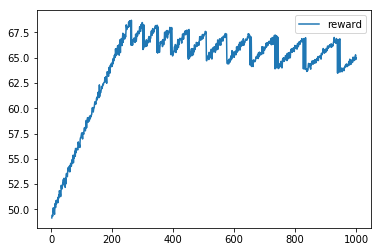

```python
plt.plot(reward_results['episode'], reward_results['reward'], label='reward')
plt.legend()
_ = plt.ylim()
```

# Land

```python
import sys
import pandas as pd
import numpy as np
from agents.ddpg_agent import DDPG
from combined import Task
import csv

num_episodes = 2000
target_pos = np.array([0., 0., 0.])
init_pos = np.array([0., 0., 10., 0., 0., 0. ])

task = Task(init_pose = init_pos, target_pos=target_pos)
agent = DDPG(task)
np.set_printoptions(precision=3)

reward_labels = ['episode', 'reward']
reward_results = {x : [] for x in reward_labels}
```

```python
stop_training = False
for i_episode in range(1, num_episodes+1):
    state = agent.reset_episode() # start a new episode
    if stop_training:
        print("Training Stopped")
        break
    while True:
        action = agent.act(state)
        action_all = action*4
        next_state, reward, done = task.step(action_all)
        if i_episode % 100 == 0:
            print(reward, action, state)
        agent.step(action, reward, next_state, done)
        state = next_state
        if done:
            if  agent.score > 27.5:
                stop_training = True

#                 print(task.sim.pose[:3], reward, action, task.sim.time) #state[:3]
            print("\rEpisode = {:4d}, score = {:7.3f} , best = {:7.3f} , timesteps = {:7.3f}, last action = {}, last pos = {}, sim time = {:7.3f}".format(
               i_episode, agent.score, agent.best_score , agent.count, action , task.sim.pose[:3], task.sim.time), end="")
            break
    reward_results['episode'].append(i_episode)
    reward_results['reward'].append(agent.score)
    sys.stdout.flush()
```

```
Episode =   99, score = -44.740 , best =  -0.039 , timesteps =  42.000, last action = [441.63496186042966], last pos = [ 0.     0.    29.695], sim time =   5.040-0.03953486692297936 [446.4232439240879] [10.0, 10.0, 10.0, 10.0, 10.0, 10.0]
-0.2424017114321142 [446.0917921995409] [10.    10.002 10.004 10.007 10.011 10.016]
-0.6316308721816561 [446.86549032803566] [10.021 10.028 10.035 10.043 10.052 10.062]
-1.2079721106900028 [446.6024310491669] [10.073 10.085 10.097 10.111 10.125 10.14 ]
-1.9689632722041388 [446.21699925675324] [10.156 10.173 10.191 10.209 10.229 10.249]
-2.910745476100699 [445.9441985068798] [10.27  10.292 10.315 10.339 10.363 10.389]
-4.029741166745197 [446.1716633357589] [10.415 10.442 10.47  10.498 10.528 10.558]
-5.323233072417848 [446.1141797263212] [10.589 10.621 10.654 10.687 10.722 10.757]
-6.787420765450987 [445.98585126222247] [10.793 10.829 10.867 10.905 10.944 10.984]
-8.417569516442892 [445.6853561820703] [11.025 11.066 11.109 11.152 11.195 11.24 ]
-10.208197403743407 [445.5320168706221] [11.285 11.331 11.378 11.426 11.474 11.523]
-12.15435486757871 [445.84557466337304] [11.573 11.623 11.674 11.726 11.779 11.832]
-14.251510854391121 [445.2977391400372] [11.886 11.941 11.997 12.053 12.11  12.167]
-16.493303380387797 [445.4934948777105] [12.226 12.285 12.344 12.405 12.465 12.527]
-18.874838886941074 [445.52356536184845] [12.589 12.652 12.716 12.78  12.845 12.911]
-21.391202246834084 [445.7437715205482] [12.977 13.044 13.111 13.179 13.248 13.317]
-24.037280264305064 [445.36918062378817] [13.387 13.457 13.529 13.6   13.673 13.746]
-26.8065296195096 [445.31348061151874] [13.819 13.893 13.968 14.043 14.119 14.195]
-29.693052163984248 [445.2463712098364] [14.272 14.35  14.428 14.506 14.585 14.665]
-32.69099497381154 [445.0263732910204] [14.745 14.826 14.907 14.989 15.071 15.154]
-35.7941177574466 [444.80817077722503] [15.237 15.321 15.405 15.49  15.575 15.661]
-38.996323418935084 [444.6925421447676] [15.747 15.834 15.921 16.009 16.097 16.185]
-42.292081825614915 [444.6919104095156] [16.274 16.364 16.454 16.544 16.635 16.726]
-45.6759988425957 [444.2639464981561] [16.817 16.909 17.002 17.095 17.188 17.281]
-49.14148140211419 [443.6775755252739] [17.375 17.47  17.565 17.66  17.755 17.851]
-52.68199131552504 [443.62669130721423] [17.947 18.044 18.141 18.238 18.336 18.434]
-56.29278589008224 [443.5939544299654] [18.533 18.631 18.73  18.83  18.929 19.029]
-59.96903645557323 [442.90154310081596] [19.13  19.23  19.331 19.432 19.534 19.636]
-63.70450151492615 [442.5465646658917] [19.738 19.84  19.943 20.046 20.149 20.253]
-67.49369718688452 [441.99772345353] [20.356 20.461 20.565 20.669 20.774 20.879]
-71.3311693437106 [441.5856456580928] [20.984 21.09  21.196 21.302 21.408 21.514]
-75.21203699890654 [441.15512220326025] [21.621 21.728 21.835 21.942 22.049 22.157]
-79.13200112917605 [441.0280639770847] [22.265 22.373 22.481 22.589 22.698 22.807]
-83.08787838712576 [440.88880555215616] [22.915 23.025 23.134 23.243 23.353 23.462]
-87.077009363121 [440.971967270176] [23.572 23.682 23.793 23.903 24.013 24.124]
-91.09728532570753 [440.794851601365] [24.235 24.346 24.457 24.568 24.68  24.791]
-95.14633612433359 [440.8935134260327] [24.903 25.015 25.127 25.239 25.351 25.463]
-99.22242005536901 [440.8061525664451] [25.576 25.688 25.801 25.914 26.027 26.14 ]
-103.32382393965469 [441.0568398149376] [26.253 26.367 26.48  26.594 26.707 26.821]
-107.4492542814392 [440.7059346386838] [26.935 27.049 27.163 27.278 27.392 27.507]
```

[output cut: 576 more lines]

```
37.038191377637375 [419.5360155732565] [4.281 4.227 4.173 4.119 4.066 4.012]
38.9175163137956 [421.31440669344124] [3.959 3.906 3.853 3.8   3.748 3.695]
40.749331888039364 [423.6571243289437] [3.643 3.591 3.539 3.488 3.436 3.385]
42.52197904432286 [426.13479499492746] [3.334 3.284 3.233 3.183 3.133 3.084]
44.22305213347958 [428.27017918475315] [3.034 2.985 2.937 2.888 2.84  2.793]
45.84099630651465 [430.1507933369933] [2.746 2.699 2.652 2.606 2.56  2.515]
47.36499945449955 [431.9938520021571] [2.47  2.425 2.381 2.337 2.294 2.251]
48.784288995466305 [433.8838731003991] [2.209 2.167 2.126 2.085 2.044 2.004]
50.08792952139515 [435.6931068188175] [1.965 1.926 1.888 1.85  1.812 1.775]
51.264806703223556 [437.8455851031728] [1.739 1.704 1.668 1.634 1.6   1.567]
52.30314202673485 [439.6509829030142] [1.534 1.502 1.47  1.44  1.409 1.38 ]
53.193023270306014 [440.46535653309184] [1.351 1.323 1.295 1.268 1.242 1.217]
53.92751298546807 [441.7140203087497] [1.192 1.168 1.145 1.122 1.1   1.079]
54.4996717191853 [442.4953099812649] [1.059 1.039 1.02  1.002 0.985 0.968]
Episode = 1557, score =  27.518 , best =  27.518 , timesteps =  42.000, last action = [448.78576032417834], last pos = [0. 0. 0.], sim time =   5.040Training Stopped
```

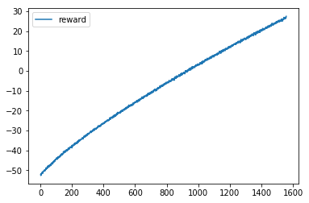

```python
import matplotlib.pyplot as plt
%matplotlib inline

plt.plot(reward_results['episode'], reward_results['reward'], label='reward')
plt.legend()
_ = plt.ylim()
```

# Hover

```python
import sys
import pandas as pd
import numpy as np
from agents.ddpg_agent import DDPG
from combined import Task

num_episodes = 2000
target_pos = np.array([0., 0., 10.]) #same as initial position
init_pos = np.array([0., 0., 10., 0., 0., 0. ])

task = Task(init_pose = init_pos, target_pos=target_pos)
agent = DDPG(task)
np.set_printoptions(precision=3)

reward_labels = ['episode', 'reward']
reward_results = {x : [] for x in reward_labels}
```

```python
stop_training = False
for i_episode in range(1, num_episodes+1):
    state = agent.reset_episode() # start a new episode
    score = 0
    if stop_training:
        print("Training Stopped")
        break
    while True:
        action = agent.act(state)
        action4 = action*4
        next_state, reward, done = task.step(action4)
        if i_episode % 100 == 0:
            print(reward, action, state)
        agent.step(action, reward, next_state, done)
        state = next_state
        score += reward
        best_score = max(best_score , score)
        if done:
            if  agent.score > 29.9: #abs(state[0] - task.target_pos[2]) < 1: #or i_episode % 20 == 0:
                stop_training = True
                print(task.sim.pose[:3], reward, action, task.sim.time) #state[:3]
            print("\rEpisode = {:4d}, score = {:7.3f} (best = {:7.3f} , timesteps = {:7.3f})".format(
               i_episode, agent.score, agent.best_score , agent.count), end="")
            break
    reward_results['episode'].append(i_episode)
    reward_results['reward'].append(agent.score)
    sys.stdout.flush()
```

```
Episode =   99, score = -10.202 (best =  29.965 , timesteps =  42.000)29.964362649131957 [442.4150050597647] [10.0, 10.0, 10.0, 10.0, 10.0, 10.0]
29.781343656400004 [442.25934847260686] [10.    10.002 10.004 10.006 10.01  10.014]
29.430579063398334 [442.04430545624615] [10.019 10.025 10.032 10.039 10.047 10.056]
28.913595490076062 [442.21430640335046] [10.066 10.077 10.088 10.1   10.113 10.126]
28.23117531498314 [442.4373487614701] [10.141 10.156 10.172 10.188 10.206 10.224]
27.38453143817474 [442.2683987330053] [10.243 10.263 10.283 10.304 10.326 10.349]
26.37606950630807 [442.4963084681554] [10.373 10.397 10.422 10.448 10.474 10.502]
25.20742778326723 [442.9155061294312] [10.53  10.558 10.588 10.618 10.649 10.681]
23.880094872303907 [443.0539281943785] [10.713 10.746 10.78  10.815 10.851 10.887]
22.39732525852046 [442.5147249123647] [10.924 10.961 10.999 11.039 11.078 11.119]
20.76451124248718 [442.3710147010744] [11.16  11.202 11.245 11.288 11.332 11.377]
18.986551927877805 [442.1467978703719] [11.422 11.468 11.515 11.562 11.61  11.659]
17.068613955075968 [441.87384961034735] [11.708 11.758 11.809 11.86  11.912 11.965]
15.016178783612043 [441.64274700937057] [12.018 12.072 12.127 12.182 12.238 12.294]
12.834894936700614 [441.25802700187523] [12.351 12.409 12.467 12.526 12.585 12.645]
10.531067387864857 [440.7209600849102] [12.706 12.767 12.829 12.891 12.954 13.018]
8.111293984149746 [440.4589190662696] [13.082 13.146 13.211 13.277 13.343 13.41 ]
5.581269483940394 [440.34016200032937] [13.477 13.545 13.613 13.682 13.751 13.821]
2.94623225798426 [440.05866447389644] [13.891 13.962 14.033 14.105 14.177 14.25 ]
0.2119804829134715 [439.57092160330404] [14.323 14.397 14.471 14.546 14.621 14.696]
-2.615255633869811 [439.27205755386706] [14.772 14.849 14.925 15.003 15.08  15.159]
-5.529561548835584 [438.69343993473734] [15.237 15.316 15.395 15.475 15.555 15.636]
-8.524688751858054 [438.36302793890945] [15.717 15.798 15.88  15.962 16.045 16.127]
-11.595153504198663 [438.03045774261517] [16.211 16.294 16.378 16.462 16.547 16.632]
-14.735507330869382 [437.4101603026477] [16.717 16.803 16.889 16.975 17.062 17.149]
-17.939648926137256 [436.79162130628595] [17.236 17.324 17.411 17.5   17.588 17.677]
-21.20217269965474 [436.8127558364896] [17.766 17.855 17.945 18.035 18.125 18.215]
-24.519253643953473 [436.2812148295762] [18.306 18.397 18.488 18.579 18.671 18.763]
-27.88610235443155 [435.9041546698065] [18.855 18.947 19.04  19.133 19.226 19.319]
-31.29810522729975 [435.3295472885569] [19.413 19.506 19.6   19.694 19.789 19.883]
-34.7506491739587 [435.0456125402072] [19.978 20.073 20.168 20.264 20.359 20.455]
-38.24013231775875 [434.8088873804418] [20.551 20.647 20.743 20.84  20.936 21.033]
-41.762668005824565 [433.7615677026309] [21.13  21.227 21.324 21.422 21.519 21.617]
-45.31249281611005 [432.98579933927914] [21.715 21.813 21.911 22.009 22.108 22.206]
-48.88458439077524 [432.29478023282326] [22.305 22.404 22.502 22.601 22.7   22.8  ]
-52.475008813301955 [432.04303410667666] [22.899 22.998 23.098 23.197 23.297 23.396]
-56.081219188241896 [431.6266539330411] [23.496 23.596 23.696 23.796 23.896 23.996]
-59.700423815416755 [431.0463761056572] [24.096 24.196 24.297 24.397 24.497 24.598]
-63.32924519842849 [430.27059688249966] [24.698 24.799 24.9   25.    25.101 25.202]
-66.96409213974607 [429.7557624085317] [25.303 25.404 25.504 25.605 25.706 25.807]
```

[output cut: 325 more lines]

```
29.36486527913379 [404.57300142559615] [10.097 10.098 10.099 10.1   10.101 10.102]
29.325766804443724 [404.45719745409207] [10.103 10.104 10.105 10.106 10.107 10.109]
29.284989180014204 [403.8044817429946] [10.11  10.111 10.112 10.113 10.114 10.115]
29.2441541214475 [404.0933254028831] [10.116 10.117 10.119 10.12  10.121 10.122]
29.20253688076053 [404.39998535660294] [10.123 10.124 10.125 10.127 10.128 10.129]
29.15930494419941 [404.2039556310182] [10.13  10.131 10.132 10.133 10.135 10.136]
29.114756052372385 [404.2997281341226] [10.137 10.138 10.139 10.141 10.142 10.143]
29.069090364813647 [403.89213186089853] [10.144 10.146 10.147 10.148 10.149 10.151]
29.023327206520452 [403.9633738675186] [10.152 10.153 10.155 10.156 10.157 10.158]
28.977429779401156 [404.0275854626414] [10.16  10.161 10.162 10.163 10.165 10.166]
28.93067274403711 [404.6029893030859] [10.167 10.169 10.17  10.171 10.172 10.174]
28.881425795617382 [404.599919323473] [10.175 10.176 10.178 10.179 10.18  10.182]
28.829339848355076 [404.6592330703983] [10.183 10.184 10.186 10.187 10.189 10.19 ]
Episode =  953, score =  29.656 (best =  30.000 , timesteps =  42.000)[ 0.     0.    10.013] 29.915259826270542 [403.70387000686895] 5.0399999999999805
Episode =  954, score =  29.940 (best =  30.000 , timesteps =  42.000)Training Stopped
```

```python
# agent.actor_local.model.save_weights("actor_local.h5")
# agent.actor_target.model.save_weights("actor_target.h5")
# agent.critic_local.model.save_weights("critic_local.h5")
# agent.critic_target.model.save_weights("critic_target.h5")

# agent.actor_local.model.load_weights("actor_local.h5")
# agent.actor_target.model.load_weights("actor_target.h5")
# agent.critic_local.model.load_weights("critic_local.h5")
# agent.critic_target.model.load_weights("critic_target.h5")
```

## Hover episode simulation

```python
done = False
labels = ['time', 'z','rotor_speed']
results = {x : [] for x in labels}
state = task.reset()
while True:
    action = agent.act(state)
    action_all = action*4
    next_state, reward, done = task.step(action_all)
    to_write = [task.sim.time] + [task.sim.pose[2]] + action
    for ii in range(len(labels)):
        results[labels[ii]].append(to_write[ii])
    state = next_state
    if done:
        break
```

```
(<Figure size 2880x720 with 1 Axes>,
```

```
Text(0.5,1,'Position (Goal: Hover, Z = 10)')
```

```
Text(0.5,1,'Rotor speed')
```

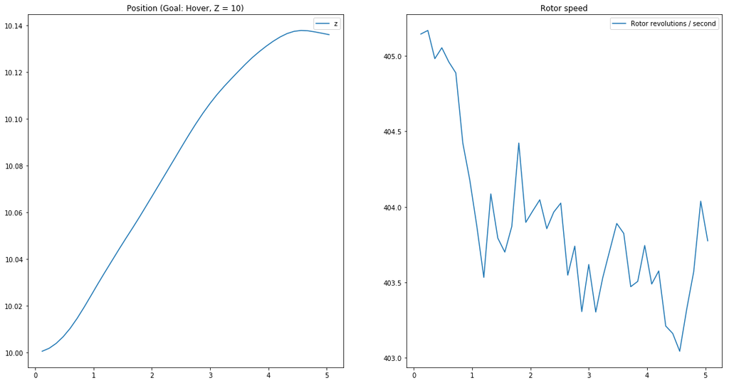

```python
plt.subplots(figsize=(40,10))
plt.subplot(141)
plt.plot(results['time'], results['z'], label='z');
plt.title("Position (Goal: Hover, Z = 10)")
plt.legend()
plt.subplot(142)
plt.plot(results['time'], results['rotor_speed'], label='Rotor revolutions / second');
plt.title("Rotor speed")
plt.legend()
```

## Hover simulation for 100 seconds

```python
done = False
labels = ['time', 'z','rotor_speed']
results = {x : [] for x in labels}
state = task.reset()
for _ in range(840):
    action = agent.act(state)
    action_all = action*4
    next_state, reward, done = task.step(action_all)
    to_write = [task.sim.time] + [task.sim.pose[2]] + action
    for ii in range(len(labels)):
        results[labels[ii]].append(to_write[ii])
    state = next_state
```

```
(<Figure size 2880x720 with 1 Axes>,
```

```
Text(0.5,1,'Position (Goal: Hover, Z = 10)')
```

```
Text(0.5,1,'Rotor speed')
```

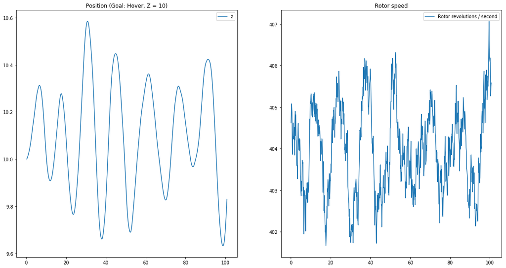

```python
import matplotlib.pyplot as plt
%matplotlib inline
plt.subplots(figsize=(40,10))
plt.subplot(141)
plt.plot(results['time'], results['z'], label='z');
plt.title("Position (Goal: Hover, Z = 10)")
plt.legend()
plt.subplot(142)
plt.plot(results['time'], results['rotor_speed'], label='Rotor revolutions / second');
plt.title("Rotor speed")
plt.legend()
```

### Without using noise

```python
# act without using noise
done = False
labels = ['time', 'z','rotor_speed']
results = {x : [] for x in labels}
state = task.reset()
for _ in range(840):
    action = agent.act(state)
    action_all = action*4
    next_state, reward, done = task.step(action_all)
    to_write = [task.sim.time] + [task.sim.pose[2]] + action
    for ii in range(len(labels)):
        results[labels[ii]].append(to_write[ii])
    state = next_state
```

```
(<Figure size 2880x720 with 1 Axes>,
```

```
Text(0.5,1,'Position (Goal: Hover, Z = 10)')
```

```
Text(0.5,1,'Rotor speed')
```

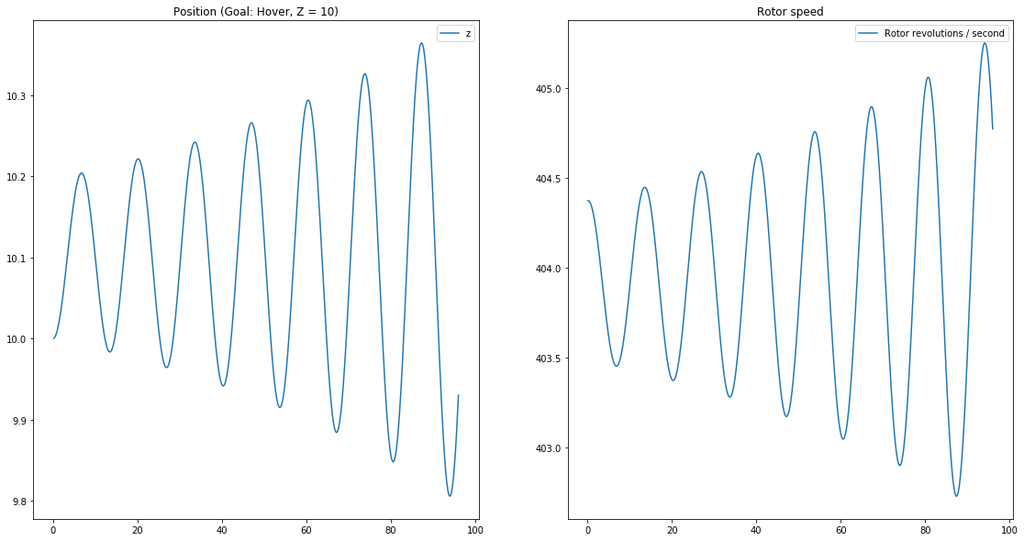

```python
import matplotlib.pyplot as plt
%matplotlib inline

plt.subplots(figsize=(40,10))
plt.subplot(141)
plt.plot(results['time'], results['z'], label='z');
plt.title("Position (Goal: Hover, Z = 10)")
plt.legend()
plt.subplot(142)
plt.plot(results['time'], results['rotor_speed'], label='Rotor revolutions / second');
plt.title("Rotor speed")
plt.legend()
```

## Reflections

**Question 1**: Describe the task that you specified in `task.py`. How did you design the reward function?

**Answer**:

I attempted to do the suggested tasks: take off, land and hover. I have tried various reward functions until I found one that was able to solve the taking off task, this is done through taking euclidean distance of the agent from the target position, then subtracted from a constant. I then tried to adapt it to achieve the hovering one until I found the current one which can perform the three tasks.

**Question 2**: Discuss your agent briefly, using the following questions as a guide:

- What learning algorithm(s) did you try? What worked best for you?
- What was your final choice of hyperparameters (such as $\alpha$, $\gamma$, $\epsilon$, etc.)?
- What neural network architecture did you use (if any)? Specify layers, sizes, activation functions, etc.

**Answer**:

I followed the project guide suggesting DDPG actor-critic model, since it's suitable for continuous actions like in here. I didn't try other learning algorithms but I did try using the implmented DDPG model in the cartpole problem to make sure it's working.

The hyper parameters chosen:

- Discount factor (gamma): 0.99
- Soft update factor (tau): 0.001
- Exploration parameters: mu : 0, theta: 0.15, sigma: .3
- Learning rate (lambda): actor: 0.00000001, critic: 0.0001

I followed the NN architecture suggested, tried multiple modifications until a good performance reached.

Actor: One hidden layer with 1600 units, added kernal regulaization, batch normalization, drop out and relu activation.

Critic: Two hidden layers with 16, 8 units, added kernal regulaization, batch normalization and relu activations.

**Question 3**: Using the episode rewards plot, discuss how the agent learned over time.

- Was it an easy task to learn or hard?
- Was there a gradual learning curve, or an aha moment?
- How good was the final performance of the agent? (e.g. mean rewards over the last 10 episodes)

**Answer**:

At first it was very difficult task when I used all states and actions parameters, the movement of the agent was erratic and it barely got to reach to one of the target position coordinates, while straying away from the rest. Then I read in the suggested material that I may not use all parameters to solve the task, and so I streamlined the states to only one, the z axis (with 6 action repeats). And the action parameters to also one, to be used for all 4 rotor revolutions. After this only, I started to see improvement in the agent performance, converging to its designated simpler one axis targets.

The take off task was quite easy to reach as a consequence, even though I had to stop the episode when reaching its destination otherwise it keeps ascending.

I interpreted the landing task to be the same as take off, only the target is 0s coordinates.

The hovering task took the most time from me to reach something reasonable. At first all I managed to get is to move slowly one way on the z axis (like from 10 to 11, or 10 to 9), this didn't really feel like hovering, just moving on a smaller scale. I found reducing the learning rate specially on the actor gave finer control over action values, and with the outcome of the reward function, I got the agent to *slowly* oscillate this behavior, so it's very near to its target position during the episode time (5 seconds) then it diverges up and down reaching 9.5 & 10.5 after 20x episode time.

**Question 4**: Briefly summarize your experience working on this project. You can use the following prompts for ideas.

- What was the hardest part of the project? (e.g. getting started, plotting, specifying the task, etc.)
- Did you find anything interesting in how the quadcopter or your agent behaved?

**Answer**:

The hardest part was by far settling on a reward function, it took so much time and it mostly felt like chasing wild goose! Specially while trying to tinker with other hyper parameters, even though they didn't matter as much as this task objective function. Aside from that, I noticed the following points:

- Due to the given reward function, the agent is susceptible to oscillating back and forth during training or getting stuck on local minima, this behavior couldn't be mitigated specially when the learning rate was higher, reducing it made the cycling taking longer time, and I eventually put an early stopping high score to end training.
- The initial action speed is important in training, when tried to decrease the maximum speed, the agent took a lower initial speed and it couldn't recover from it, always opting for crashing on the ground.
- As I see it, the hovering task was the most difficult one because the agent needs to move down if it's higher than its target, move up when it's lower, and move randomly when it's 'around' its target. The solution attempted can solve this during the episode time, whereas it diverges on the long run.